# Basic Bayes

Martin Ingram

05/08/2019

- Welcome
- Stan & R setup; download
- Planned Schedule
- Disclaimer!

Download link: https://bit.ly/2YWgqMg

Schedule:

- 10.00am-10.40am: Basic Bayes – Bayes’ rule examples
- 10.40am-11.00am: Basic Bayes exercises
- 11.00am-11.40am: Intro to MCMC
- 11.40am-12.00pm: MCMC exercises
- 12pm-1pm: Lunch break
- 1pm-1.40pm: Bayesian logistic regression (species distribution example)
- 1.40pm-2pm: Exercises
- 2pm-2.40pm: Hierarchical models
- 2.40pm-3pm: Exercises

# Intro to Bayes’ rule

Let’s start off with something we’ll call:

$$p(\theta)$$

This is the so-called *prior* probability: our belief about $\theta$ before we have any data. For example, if someone asks you what the probability is that it’ll rain tomorrow (that’s $p(\theta = 1)$), you can probably make up some number.

Bayes’ rule is all about going from *prior* to *posterior* probability. We have a prior $p(\theta)$, as we just described; then we observe some data, $y$. We want to know how we should update our belief about $\theta$. For example, if you now see that the weather forecast for tomorrow says it’ll probably rain, you might want to update your belief (but perhaps you don’t fully trust the weather forecast, so you don’t just accept it completely).

What we want is the so-called *posterior distribution*:

$$p(\theta | y)$$

This is the updated distribution of $\theta$ *given* our new data $y$. Bayes’ rule tells us how to get from $p(\theta)$ to $p(\theta | y)$:

$$p(\theta | y) = \frac{p(\theta) p(y | \theta)}{p(y)}$$

There are two other terms in here we should get familiar with. Firstly:

$$p(y | \theta)$$

This is the *likelihood* of the data we observe for a given parameter $\theta$. The likelihood is how data enters into the model and is what will make us revise our beliefs.

Finally, $p(y)$ normalises the product of the prior and the likelihood to sum to 1. Today, this term will mainly be a nuisance (we’ll see why), but it can be useful for some purposes.

## An example of using Bayes’ rule with binary events

Sometimes, Bayes’ rule can lead to surprising results, even in simple cases. For example, consider the following scenario.

```
You go to see the doctor. As part of a checkup, the doctor tests you for a rare disease, e.g. cancer. This particular disease affects 1 in 1000 people of your age. If you have the disease, the test will test positive with 99% probability. If you don't have the disease, the test will give a negative with 99% probability. You test positive. How worried should you be?
```

Let’s translate this into the language of probabilities:

$$p(D = 1) = \frac{1}{1000} \\
p(T = 1|D = 1) = 0.99 \\
p(T = 0|D = 0) = 0.99$$

What we want is $p(D = 1 | T = 1)$. This is exactly the situation of Bayes’ rule: we have a prior probability $p(D)$, we get new data (the positive test result, $T = 1$), and we want to find our new probability of having the disease. We know $p(T|D)$, the likelihood. So:

$$p(D = 1|T = 1) = \frac{p(D = 1)p(T = 1|D = 1)}{p(T = 1)} = \frac{\frac{0.99}{1000}}{p(T = 1)}$$

What’s $p(T = 1)$? We’re not going to go into probability theory here much, but we need two rules from it to solve the denominator: marginalisation and conditioning:

1. Marginalisation: If we have $p(A, B)$, we can get $p(A)$ by summing out all possibilities for $B$. For example, if $B$ can be either 1 or 0 (true or false), then $p(A) = p(A, B=0) + p(A, B=1)$.
2. Conditioning: We’ve already seen the $|$ sign in $p(y|\theta)$. Conditional probabilities are defined as: $p(A|B) = \frac{p(A, B)}{p(B)}$. Rearranging, we can find a useful identity: $p(A|B)p(B) = p(A, B)$.

These rules aren’t that complicated, but they do take time to master. We’ll be using simulation to do practical work later, so it’s not that important that you understand this fully. But I didn’t want to just use them without introducing them. Anyway, with those two tools, we can calculate $p(T=1)$:

$$p(T = 1) = p(T = 1, D = 0) + p(T = 1, D = 1) = \textrm{ (using marginalisation)} \\
p(T = 1|D = 0)p(D = 0) + p(T = 1 | D = 1)p(D = 1) = \textrm{ (using conditioning)} \\
(1 - 0.99) (1 - \frac{1}{1000}) + 0.99 \frac{1}{1000} \textrm{ (using that } p(T = 1 | D = 0) = 1 - p(T = 0 | D = 0) )$$
If you want to really understand what’s going on here, I highly recommend Joe Blitzstein’s online course “Introduction to Probability” as well as his book:

- Course homepage: https://projects.iq.harvard.edu/stat110/home
- Videos: https://www.youtube.com/playlist?list=PL2SOU6wwxB0uwwH80KTQ6ht66KWxbzTIo

Anyway, let’s calculate that:

```r
denominator <- (1 - 0.99) * (1 - (1 / 1000)) + 0.99 / 1000
numerator <- 0.99 / 1000

numerator / denominator
```

```
## [1] 0.09016393
```

So our new probability is just over 9%. Not tiny, maybe big enough to get a little bit queasy, but it’s still pretty unlikely that we have the disease. We could take another test to get more information, where our prior would now be $p(D = 1) \approx 0.09$.

## Bayesian coin tosses

Another simple Bayesian example involves repeated samples with the same success probability.

Let’s say someone gives you a coin and you want to work out the probability it comes up heads. This example might be contrived (people don’t usually give us coins to test for fairness), but keep in mind that things in probability are often *isomorphic*: maybe you don’t care about coins, but you’re interested in someone’s probability of scoring a penalty in soccer, or in how likely you are to see a particular animal when you repeatedly visit a site.

Anyway, the example: what we’re interested in is $\theta$, the probability that the coin comes up heads when tossed. We’ll say that this coin *could* be biased: we don’t know (otherwise it’s just 50% and boring).

If we want to use Bayes’ theorem here, we first need a prior. To keep things simple, we’ll start off with a Uniform distribution:

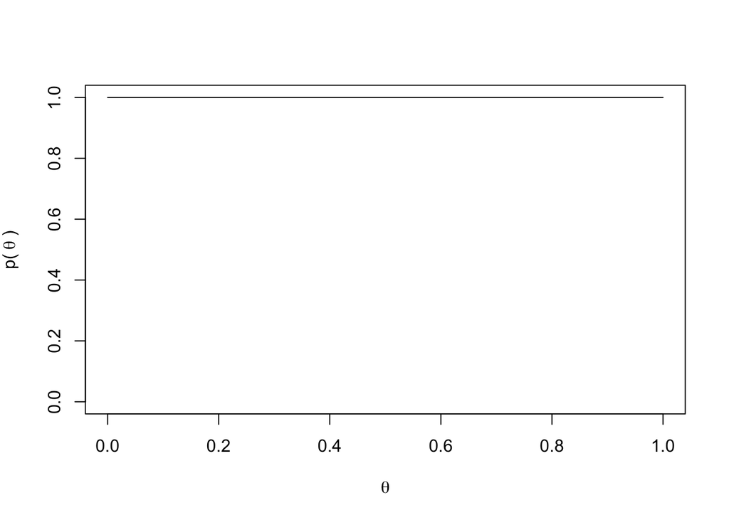

```r
x <- seq(0, 1, length.out=100)
y <- rep(1, 100)

plot(x, y, ylim=c(0, 1), xlab=expression(theta), ylab=expression('p(' ~ theta ~ ')'), type='l')
```

Let’s really understand what this means. We’re saying that we have absolutely no clue what the probability $\theta$ is that the coin comes up heads, so we’re giving *every possible value* $\theta$ the same prior probability.

Now, we need a likelihood. In this case, we’ll use the Bernoulli likelihood. It looks like this:

$$p(y = 1|\theta) = \theta \\
p(y = 0|\theta) = 1 - \theta$$

So now we have our prior and likelihood. Let’s say we toss the coin and it comes up heads. What’s our new belief about $\theta$? Once again, we use Bayes’ rule:

$$p(\theta | y = 1) = \frac{p(\theta) p(y = 1 | \theta)}{p(y = 1)}$$

Since we’re using a uniform prior here, $p(\theta)$ is just 1. So, Bayes’ rule becomes:

$$p(\theta | y = 1) = \frac{\theta}{\int_{0}^1 p(y = 1 | \theta) p(\theta) d\theta} = \frac{\theta}{\int_{0}^1 \theta d\theta} = \frac{\theta}{0.5} = 2\theta$$
Check it out: the denominator was the tough part again. There, we used the same trick as before to break $p(y, \theta)$ into $p(y|\theta)p(\theta)$; the only difference is that we now need to use an integral rather than a sum because we can have any number for $\theta$ between 0 and 1. Again: the main message is that this is a bit complicated and we’ll have a way to avoid this later on.

So our posterior is now (drawn in red below; green is the prior):

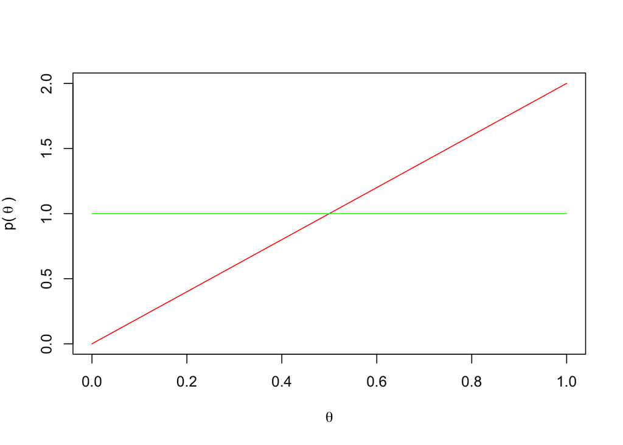

```r
theta_plot <- function(x, y, ylim=NULL) {
  plot(x, y, xlab=expression(theta), ylab=expression('p(' ~ theta ~ ')'), type='l', col='red', ylim=ylim)
}

x <- seq(0, 1, length.out=100)
yprior <- rep(1, 100)
ypost <- 2 * x

theta_plot(x, ypost)
lines(x, yprior, ylim=c(0, 2), col='green')
```

I’m guessing you probably don’t particularly like integrals. And this one was an easy one! We’d have to solve one every time we toss a new coin, and they get a bit more complicated. Luckily, this particular problem has a solution: it turns out that if our prior is a so-called Beta distribution:

$$p(\theta) = \textrm{Beta}(\theta | \alpha, \beta) \\
\textrm{often also written as } \theta \sim \textrm{Beta}(\alpha, \beta)$$

You’ll see the second version often in the literature: $\theta$ *is distributed as* $\textrm{Beta}(\alpha, \beta)$.

If this is the case and we observe heads ($y = 1$), then our posterior is:

$$p(\theta | y = 1) \sim \textrm{Beta}(\alpha + 1, \beta)$$
And if we observe tails ($y = 0$), then our posterior is:

$$p(\theta | y = 0) \sim \textrm{Beta}(\alpha, \beta + 1)$$

In other words, if we observe a success, we increment the first parameter of the Beta distribution. If we observe a failure, we increment the second. Let’s see what this looks like:

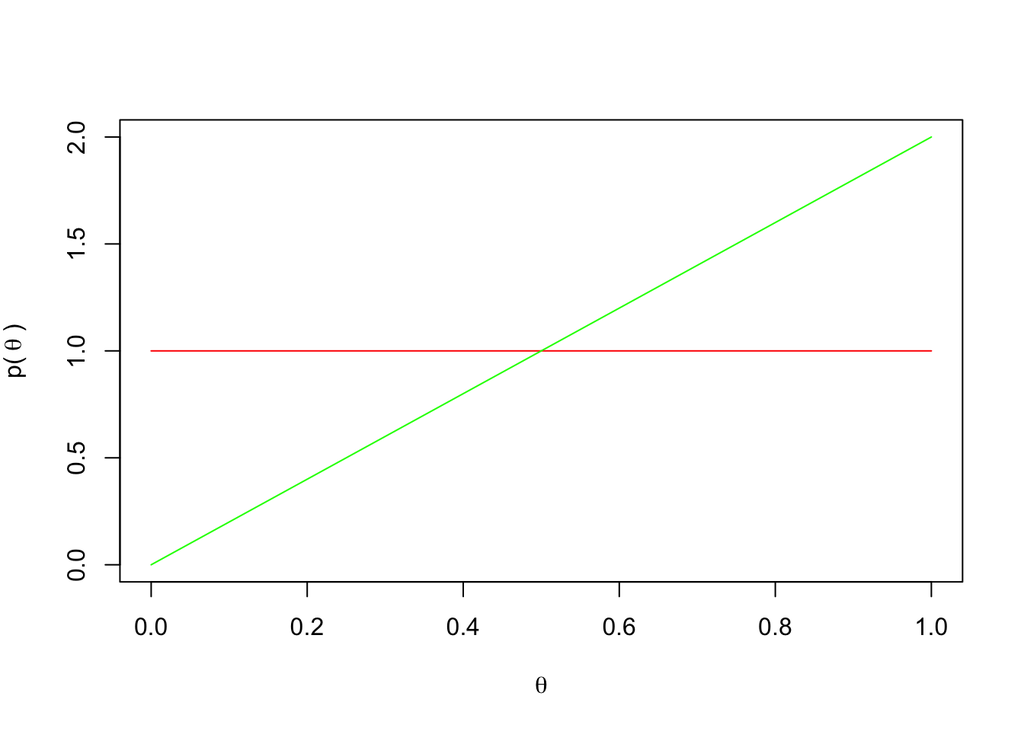

```r
x <- seq(0, 1, length.out = 100)

# Uniform prior:
prior <- dbeta(x, 1, 1)

# Posterior after observing one head
post <- dbeta(x, 2, 1)

theta_plot(x, prior, ylim=c(0, 2))
lines(x, post, col='green')
```

The same as before! Note that seeing heads makes the posterior distribution go to zero at $\theta=0$; we know that the value can’t be 0 because the coin came up heads, so there’s at least some probability of that happening.

OK, let’s do something more interesting. Suppose you toss the coin 10 times and it comes up heads 6 times. We can think of this as 10 successive updates with a Bernoulli likelihood. What’s your posterior now? We won’t prove this, but it turns out that it’s:

$$p(\theta | y_1, y_2, ... y_{10}) = \textrm{Beta}(1 + 6, 1 + 4) = \textrm{Beta}(7, 5)$$

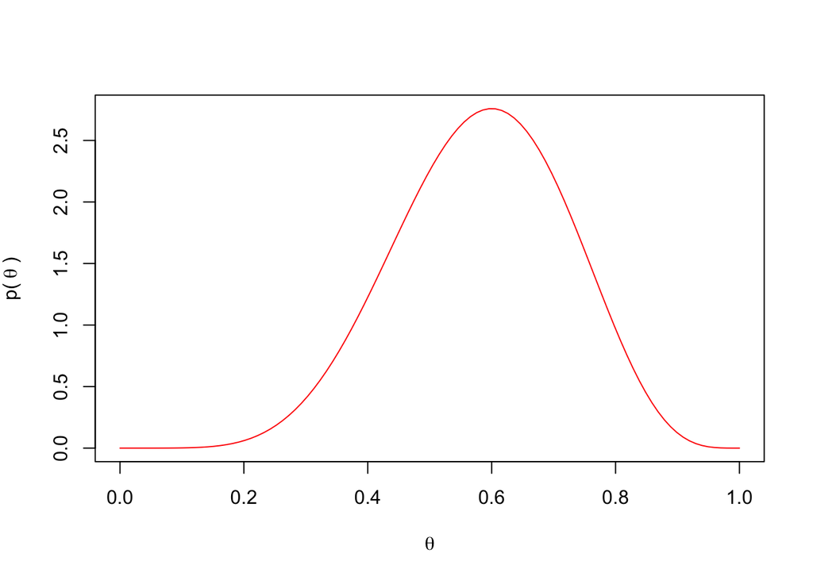

```r
x <- seq(0, 1, length.out = 100)
n_heads <- 6
n_tails <- 4

# Posterior after observing one head
posterior <- dbeta(x, n_heads + 1, n_tails + 1)

theta_plot(x, posterior)
```

We can now answer some questions about this. If we had to guess a mean success probability, what would that be? We could use the Beta distribution to calculate these exactly, but let’s do it via simulation instead (we’ll do that from now on). We’ll draw from this distribution a few thousand times and compute what we’re interested in. This is called a “Monte Carlo” estimate.

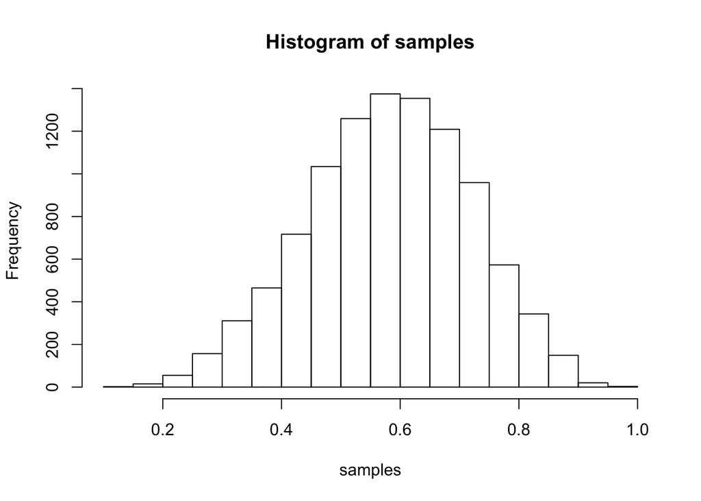

```r
n_draws <- 10000
samples <- rbeta(n_draws, 1 + n_heads, 1 + n_tails)

hist(samples)
```

The mean is:

```r
mean(samples)
```

```
## [1] 0.5818042
```

And the probability that the success probability is greater than 60% is approximately equal to the fraction of draws greater than 60%, so:

```r
mean(samples > 0.6)
```

```
## [1] 0.461
```

As we observe more and more tosses, the distribution gets narrower and narrower, reflecting us gaining more and more knowledge:

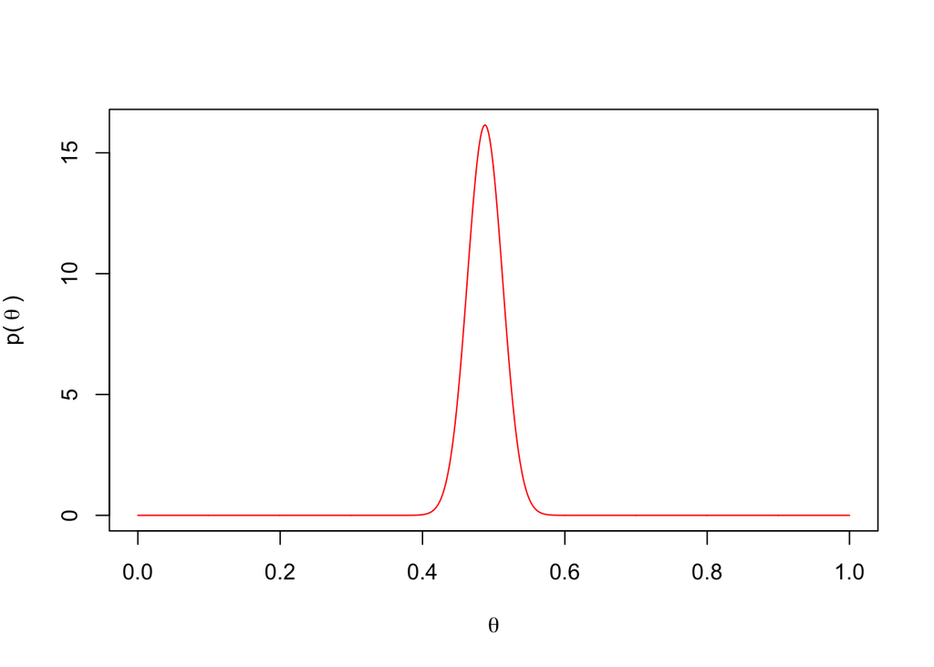

```r
x <- seq(0, 1, length.out = 1000)
n_heads <- 200
n_tails <- 210

posterior <- dbeta(x, n_heads, n_tails)

theta_plot(x, posterior)
```

This also meshes with the intuitive idea that we calculate the ratio of heads / (heads + tails) for an estimate of $\theta$:

```r
print('Ratio estimate:')
```

```
## [1] "Ratio estimate:"
```

```r
print(n_heads / (n_heads + n_tails))
```

```
## [1] 0.4878049
```

```r
print('Approximate Beta(210, 200) mean:')
```

```
## [1] "Approximate Beta(210, 200) mean:"
```

```r
print(mean(rbeta(1e6, n_heads, n_tails)))
```

```
## [1] 0.4878085
```

So for large numbers of trials, these estimates are quite similar, but they differ at small sample sizes. For example, we would predict $\theta = \frac{1}{1} = 1$ using the ratio with one trial and one success, compared to a posterior mean of about:

```r
mean(rbeta(1e6, 2, 1))
```

```
## [1] 0.6670274
```

Using the Bayesian version, which is arguably more reasonable.

## Exercises

##### Exercise 1

(well-known) You play poker with the Archbishop of Canterbury. It turns out that he has a royal flush, which has a probability of only $1.54 \times 10^{-6}$. However, being a reputable man, you believe it is very unlikely that the Archbishop would cheat – say 1 in a million, $1 \times 10^{-6}$. Use Bayes’ rule to work out the probability that the Archbishop cheated. Hint: this is very similar to our disease example!

##### Exercise 2

You play tennis against your friend 5 times. You win 4 times and lose once. Assuming you had no idea how likely you were to win initially, what is the posterior distribution of your win probability? What is the probability that your win probability is greater than 50%?